# Peer-graded Assignment: Prediction Assignment Writeup

Jón Guttesen

8 jul 2017

## Executive Summary

This paper will present a model for predicting class of exercise based a number of measurements from personal devices.

Initialy the data will be loaded and processed. Secondly a model will be constructed for predicting class. The model cross validation will be performed and the expected out of sample error reported.

Finaly a classification of 20 test cases is performed based on the model and the result presented.

## Background

Using devices such as Jawbone Up, Nike FuelBand, and Fitbit it is now possible to collect a large amount of data about personal activity relatively inexpensively. These type of devices are part of the quantified self movement – a group of enthusiasts who take measurements about themselves regularly to improve their health, to find patterns in their behavior, or because they are tech geeks. One thing that people regularly do is quantify how much of a particular activity they do, but they rarely quantify how well they do it. In this project, your goal will be to use data from accelerometers on the belt, forearm, arm, and dumbell of 6 participants. They were asked to perform barbell lifts correctly and incorrectly in 5 different ways. More information is available from the website here: http://groupware.les.inf.puc-rio.br/har (see the section on the Weight Lifting Exercise Dataset).

The training data for this project are available here: https://d396qusza40orc.cloudfront.net/predmachlearn/pml-training.csv

The test data are available here: https://d396qusza40orc.cloudfront.net/predmachlearn/pml-testing.csv

## Analasys

### Setup

```r
library(caret)
set.seed(1234)
```

### Data processing

The training file will be downloaded. Non pertinent columns will be removed and columns with missing values will be removed.

```r
trainurl = "https://d396qusza40orc.cloudfront.net/predmachlearn/pml-training.csv"
trainfilename = "pml-training.csv"
if( !file.exists(trainfilename))
  download.file(trainurl, trainfilename)
training <- read.csv(trainfilename, na.strings = c('', 'NA') )

#columns which are not useful for prediction
training <- training[,-seq(1,7)]


#columns with n/a values
training <- training[, -which(colMeans(is.na(training)) > 0)]

#nzv <- nearZeroVar(training)
#training <- training[, -nzv]

#f2 <- function(x) is.factor(x) && (nlevels(x) < 2)
#training <- training[, sapply(training,  f2) == FALSE]

#partition data with 20% training and 80% testing
inTrain  <- createDataPartition( training$classe, p=0.8, list = FALSE)

training <- training[inTrain, ]
testing  <- training[-inTrain, ]
```

### Model building

A random forrest model will be constructed. The properties of the model will be presented, out of sample error rate and the variables of importance.

```r
model = train( classe ~ ., data=training, method="rf", verbose = TRUE, importance = TRUE, ntree=5 )
model$finalModel
```

```
##
## Call:
##  randomForest(x = x, y = y, ntree = 5, mtry = param$mtry, importance = TRUE,      verbose = TRUE)
##                Type of random forest: classification
##                      Number of trees: 5
## No. of variables tried at each split: 27
##
##         OOB estimate of  error rate: 5.11%
## Confusion matrix:
##      A    B    C    D    E class.error
## A 3898   70   19   18    6  0.02817253
## B   69 2553   53   25   35  0.06654479
## C    9   89 2276   60   12  0.06950123
## D   14   32   70 2178   30  0.06282272
## E   11   46   26   28 2500  0.04251245
```

```r
prediction <- predict(model, newdata=testing)
confMatRandForest <- confusionMatrix(prediction, testing$classe)
confMatRandForest
```

```
## Confusion Matrix and Statistics
##
##           Reference
## Prediction   A   B   C   D   E
##          A 891   0   0   0   0
##          B   0 639   0   0   0
##          C   0   0 513   1   0
##          D   0   0   0 518   0
##          E   0   0   0   0 578
##
## Overall Statistics
##
##                Accuracy : 0.9997
##                  95% CI : (0.9982, 1)
##     No Information Rate : 0.2838
##     P-Value [Acc > NIR] : < 2.2e-16
##
##                   Kappa : 0.9996
##  Mcnemar's Test P-Value : NA
##
## Statistics by Class:
##
##                      Class: A Class: B Class: C Class: D Class: E
## Sensitivity            1.0000   1.0000   1.0000   0.9981   1.0000
## Specificity            1.0000   1.0000   0.9996   1.0000   1.0000
## Pos Pred Value         1.0000   1.0000   0.9981   1.0000   1.0000
## Neg Pred Value         1.0000   1.0000   1.0000   0.9996   1.0000
## Prevalence             0.2838   0.2035   0.1634   0.1653   0.1841
## Detection Rate         0.2838   0.2035   0.1634   0.1650   0.1841
## Detection Prevalence   0.2838   0.2035   0.1637   0.1650   0.1841
## Balanced Accuracy      1.0000   1.0000   0.9998   0.9990   1.0000
```

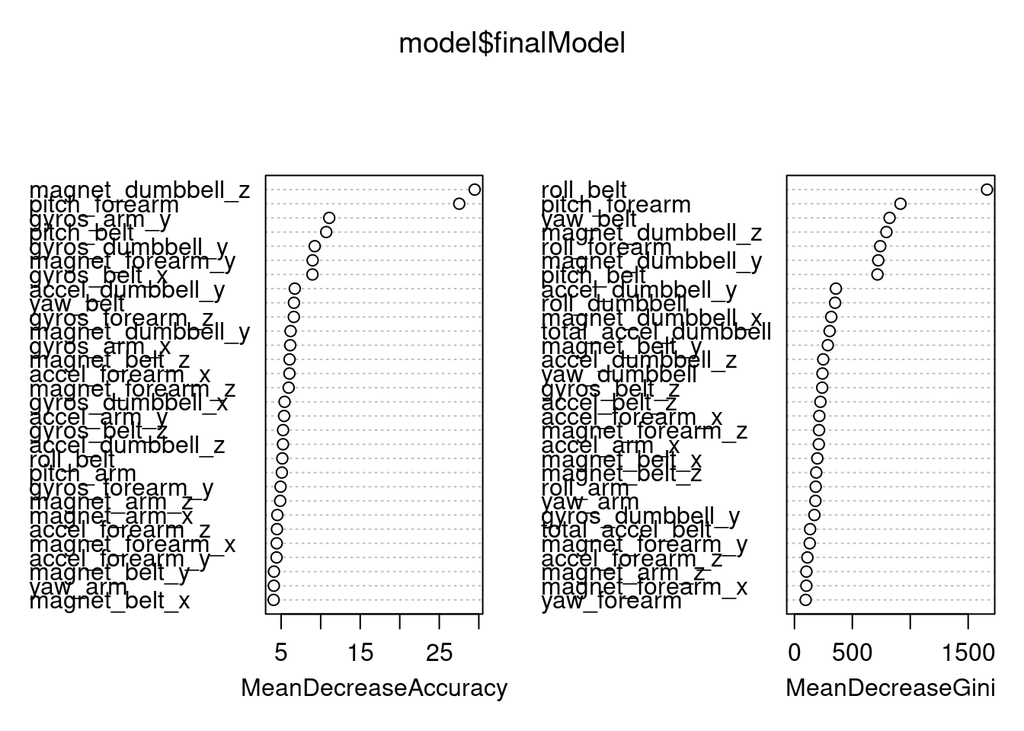

```r
varImpPlot(model$finalModel)
```

```r
varImp(model$finalModel)
```

```
##                               A         B         C          D          E
## roll_belt             3.0678914  8.339026  4.339568  3.8732914  6.5574485
## pitch_belt            8.3500488  9.623609  8.409414  4.8301263  7.3948484
## yaw_belt              3.2389806  7.219874  6.557732  4.5759925  9.3895516
## total_accel_belt      1.4092547  1.202720  1.118034  1.1180340  1.1180340
## gyros_belt_x          2.7528237  3.170067  3.214920  1.3600943  0.7862583
## gyros_belt_y          2.0337992  2.314812  1.709313  2.6338739  4.1976394
## gyros_belt_z          3.0897559  3.512696  4.431917  2.5236143  3.9933749
## accel_belt_x          1.7839588  1.716020  1.426083  2.4979479  2.2004538
## accel_belt_y          1.1180340  1.176460  1.293117  1.1290420  2.1307855
## accel_belt_z          2.3581636  2.186080  1.243785  2.3318965  1.6653158
## magnet_belt_x         4.3370150  3.196054  2.408712  2.8961086  2.4891799
## magnet_belt_y         1.6702065 12.873285  7.168214  1.2801121  3.1326043
## magnet_belt_z         2.5146267  3.099898  3.725676  4.5331922  2.6084088
## roll_arm              1.8015985  2.699378  1.926040  2.2217220  1.5102844
## pitch_arm             2.4079378  3.217306  2.143970  2.4114420  2.5223881
## yaw_arm               5.5610803  4.545443  2.734846  3.1196052  2.0483131
## total_accel_arm       2.2895065  2.531032  1.761193  7.7213718  2.9388281
## gyros_arm_x           2.1216193  3.968072  1.826147  5.1608424  3.2646102
## gyros_arm_y           5.7583837  6.444203  2.033881  2.8846884 14.0292790
## gyros_arm_z           3.1568159  1.060178  2.597297  0.2663375  1.8399393
## accel_arm_x           2.0814211  1.841495  2.068819  2.5253308  1.4595329
## accel_arm_y           2.4663573  3.485170  2.421161  3.8250994  4.6343641
## accel_arm_z           2.3671167  3.850766  1.574590  2.5404587  1.6865093
## magnet_arm_x          1.5409665  3.518985  3.814468  3.6690651  1.5619155
## magnet_arm_y          3.1258766  2.027358  2.598946  2.3498409  1.6420865
## magnet_arm_z          2.7056284  2.803972  6.958425  1.4921037  2.7898191
## roll_dumbbell         1.5851369  2.559607  2.464755  2.3069872  2.8518776
## pitch_dumbbell        1.8811314  3.716752  1.583131  2.3206049  1.9254551
## yaw_dumbbell          2.4091277  3.802127  1.831419  1.8654417  2.4746183
## total_accel_dumbbell  1.7193123  2.793564  2.464210  2.8571764  3.2058507
## gyros_dumbbell_x      4.1491514  3.008727  4.316590  4.0423272  1.3891129
## gyros_dumbbell_y      4.0128348  5.055393  4.872392  5.6328683  3.4850789
## gyros_dumbbell_z      2.3077818  2.104879  1.408531  1.5286076  0.0000000
## accel_dumbbell_x      1.6161389  2.328395  1.709074  2.4310306  3.2339879
## accel_dumbbell_y      2.5302213  6.367249  7.341925  2.9857684  6.4230906
## accel_dumbbell_z      5.8309088  4.565368  2.943149  4.4030856  4.6095604
## magnet_dumbbell_x     4.3152627  4.126131  3.205546  4.6779313  1.9874965
## magnet_dumbbell_y     7.6879576  4.126682  6.286244  6.2622566  4.4125090
## magnet_dumbbell_z    12.6039876 18.213432 10.557577  8.1010372 10.2091596
## roll_forearm          3.7170552  4.408049  4.375364  3.1390047  2.8213135
## pitch_forearm        21.8375542 17.547727 12.446609 11.0719410  6.5900930
## yaw_forearm           2.0742709  2.116000  2.605176  2.5974729  1.9843384
## total_accel_forearm   1.6182750  2.304421  3.044571  1.5195910  2.0482735
## gyros_forearm_x       0.8557297  2.777105  1.229333  1.3561955  1.4483527
## gyros_forearm_y       2.4005599  2.373393  4.801634  1.7702362  4.1004012
## gyros_forearm_z       1.3125535  6.348949  1.688010  3.0588735  4.1068267
## accel_forearm_x       2.4816718  4.902845  2.665497 11.3327844  4.3898360
## accel_forearm_y       3.0212860  2.073861  2.513311  1.6585620  1.5774141
## accel_forearm_z       2.6472476  3.605698  3.490902  2.3548580  2.8908019
## magnet_forearm_x      4.1715961  2.495991  3.454652  2.1169938  3.6895912
## magnet_forearm_y      4.0316768  2.984604  3.571951  4.2675646  2.0861149
## magnet_forearm_z      3.8490322  4.908714  3.299656  4.1348251  4.6339033
```

Notice the Out of bag estimate (OOB). This is an estimation of the out of sample error.

## Conclusion

Finaly the model will be used to predict the 20 test cases.

```r
testurl = "https://d396qusza40orc.cloudfront.net/predmachlearn/pml-testing.csv"
testfilename = "pml-testing.csv"
if( !file.exists(testfilename))
  download.file(testnurl, testfilename)
testing <- read.csv(testfilename, na.strings = c('', 'NA') )
testing <- testing[,names(testing) %in% names(training)]

#test <- predict(preObj, testing)
predict_result <- predict(model, newdata = testing)
predict_result
```

```
##  [1] B A B A A E D B A A B C B A E E A B B B
## Levels: A B C D E
```